# Data preparation

#### Error

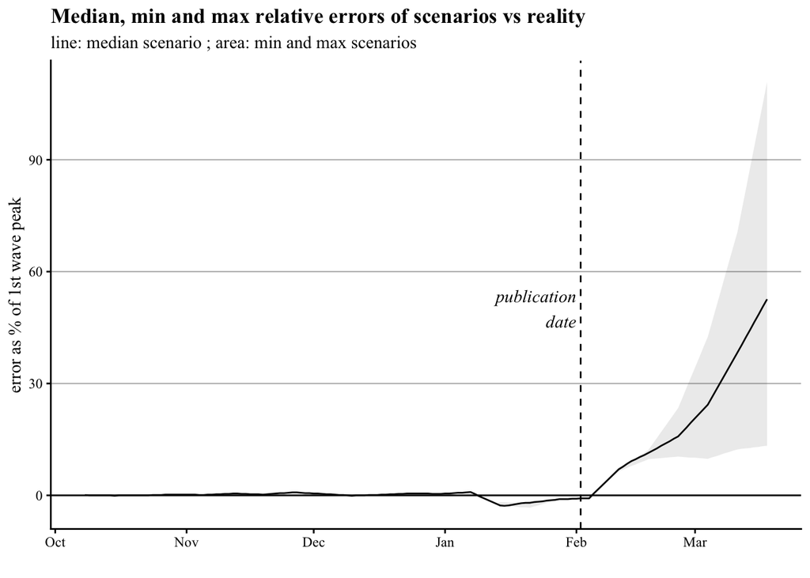

```r
error <- f_compute_error("2020-10-01", "2021-05-01", temp, max_new_hosp)

f_graph_error(
  error,
  "2021-02-02", 50 #publication date label
  )
```

```r
f_save_csv_files(error, output_path_error, "2021_02_14_new_hosp_error.csv")
```

#### Original

##### Fig 2

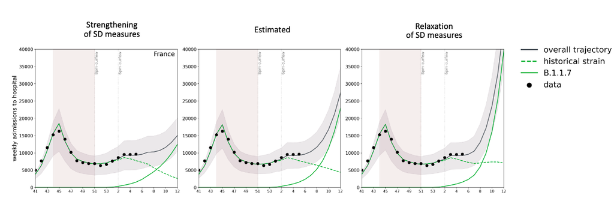

### February 23, 2021

Source: [Pasteur report](https://hal-pasteur.archives-ouvertes.fr/pasteur-03149525/document), February 23, 2021. Identified on Pasteur Institute’s website, on [this page](https://modelisation-covid19.pasteur.fr/realtime-analysis/impact-variant/).

#### Reproduced

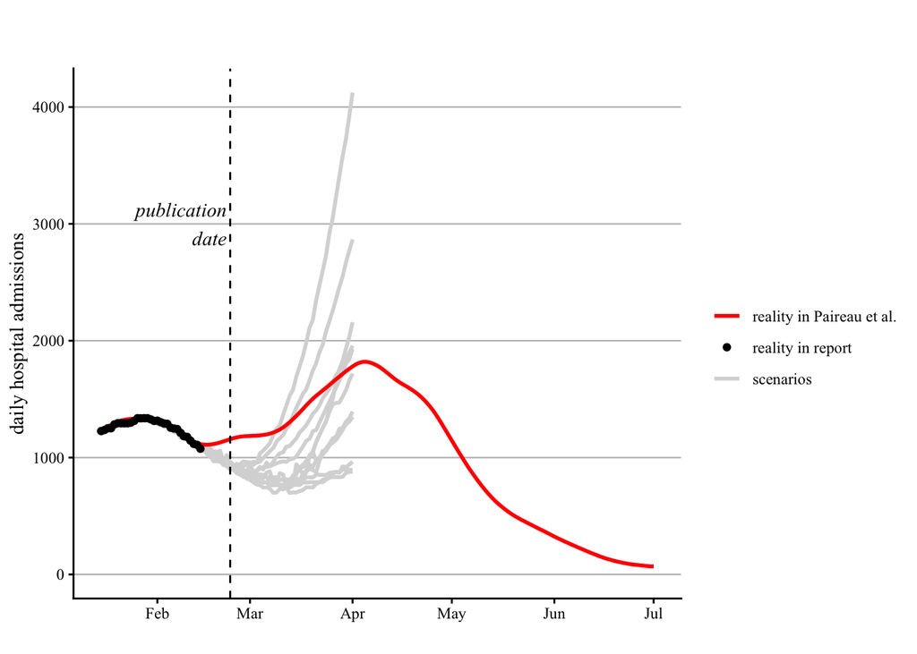

```r
#load scenario data
scenarios <- read_csv("source_data/2021_02_23/new_hosp.csv") %>%
  mutate(date = as.Date(date, format = "%Y/%m/%d", optional = T))

f_graph(
  reality_new_hosp_adm, scenarios,
  "new_hosp_smooth",
  "2021-02-23", 3000, #publication date label
  "2021-01-15", "2021-07-01", #date limits
  NA, # y limits
  "daily hospital admissions",
  "reality in Paireau et al."
)
```

```r
#prepare and save data
temp <- f_prepare_to_save(
  scenarios,
  reality_new_hosp_adm %>% select(date, new_hosp_smooth),
  "new_hosp_smooth"
  )
temp <- temp %>% filter(date <= as.Date("2021-03-22")) #stop comparison before 3rd lockdown, on March 22nd
f_save_csv_files(temp, output_path, "2021_02_23_new_hosp.csv")
```

#### Error

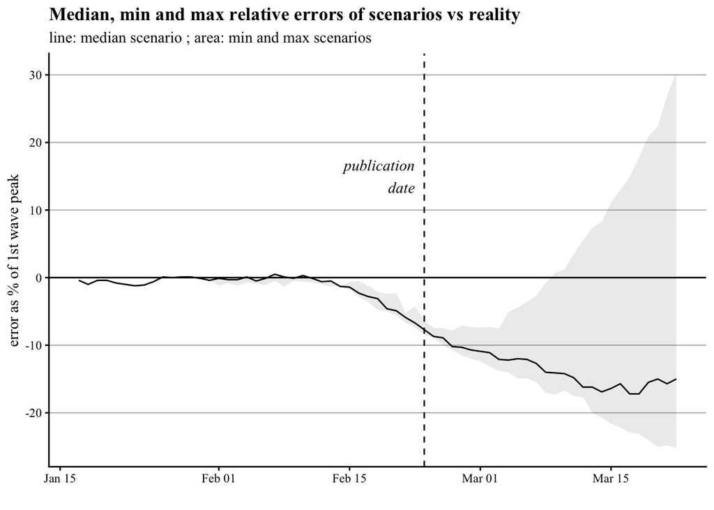

```r
error <- f_compute_error("2021-01-16", "2021-03-27", temp, max_new_hosp)

f_graph_error(
  error,
  "2021-02-23", 15 #publication date label
  )
```

```r
f_save_csv_files(error, output_path_error, "2021_02_23_new_hosp_error.csv")
```

#### Original

##### Fig 2C

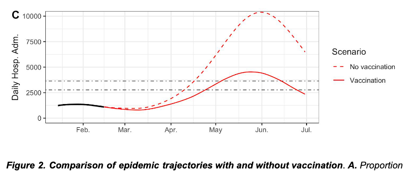

##### Fig 5A, 5C and 5E

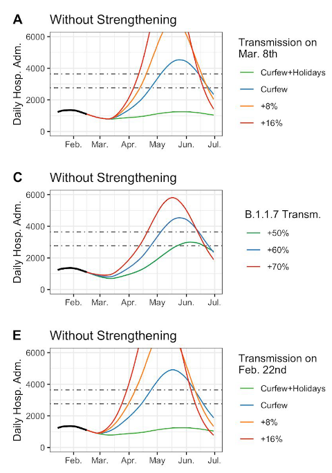

### April 26, 2021

Source: [Pasteur report](https://modelisation-covid19.pasteur.fr/loosening/Scenarios_de_levee_des_mesures_de_freinage_20210426.pdf), April 26, 2021. Identified on Pasteur Institute’s website, on [this page](https://modelisation-covid19.pasteur.fr/realtime-analysis/delta-variant-dynamic/).

#### Reproduced

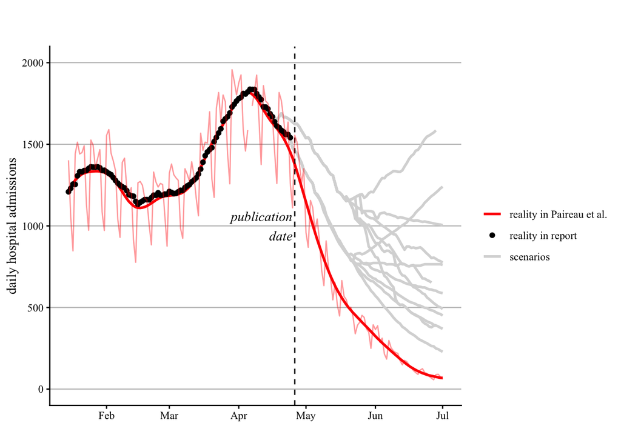

```r
#load scenarios
scenarios <- read_csv("source_data/2021_04_26/new_hosp.csv") %>%
  mutate(date = as.Date(date, format = "%Y/%m/%d", optional = T))

#graph comparison
f_graph(
  reality_new_hosp_adm, scenarios,
  "new_hosp_smooth",
  "2021-04-26", 1000, #publication date label
  "2021-01-15", "2021-07-01", #date limits
  NA, # y limits
  "daily hospital admissions",
  "reality in Paireau et al."
) +
  geom_line(
    data=reality_new_hosp_adm, aes(date, new_hosp), alpha=.4, color="red"
  )  +
  ylim(0, 2000)
```

```r
#prepare data so save
temp <- f_prepare_to_save(
  scenarios,
  reality_new_hosp_adm %>% select(date, new_hosp_smooth),
  "new_hosp_smooth"
  )

#comparison dates limits
temp <- temp %>% filter(date<=as.Date("2021-06-15")) #stop comparison mid-June before delta variant dominant

#save data
f_save_csv_files(temp, output_path, "2021_04_26_new_hosp.csv")
```

#### Error

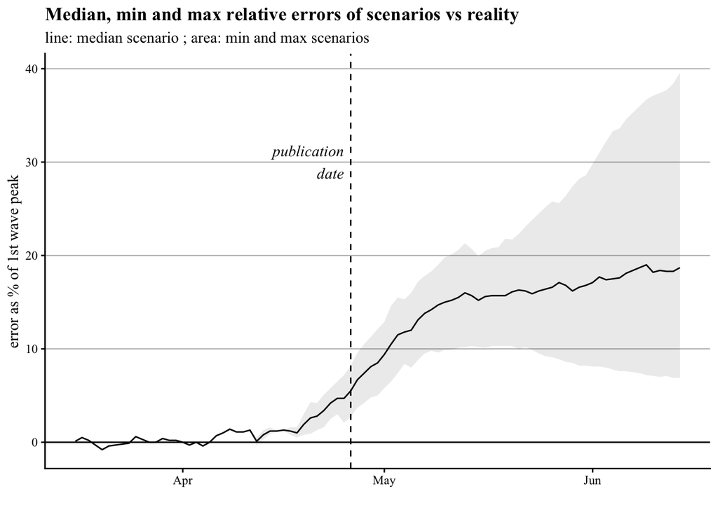

```r
error <- f_compute_error("2021-03-15", "2021-06-15", temp, max_new_hosp)

f_graph_error(error,
 "2021-04-26", 30 #publication date label
  )
```

```r
f_save_csv_files(error, output_path_error, "2021_04_26_new_hosp_error.csv")
```

#### Original

##### Fig 3B and 3D

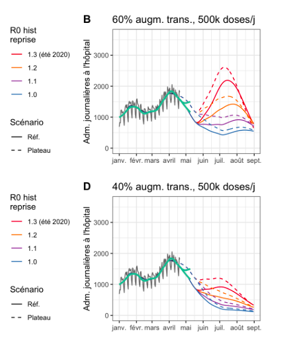

### May 21, 2021

Source: [Pasteur report](https://modelisation-covid19.pasteur.fr/loosening/Mise_a_jour_scenarios_de_levee_des_mesures_de_freinage_20210521.pdf), May 21, 2021. Identified on Pasteur Institute’s website, on [this page](https://modelisation-covid19.pasteur.fr/realtime-analysis/delta-variant-dynamic/).

#### Reproduced

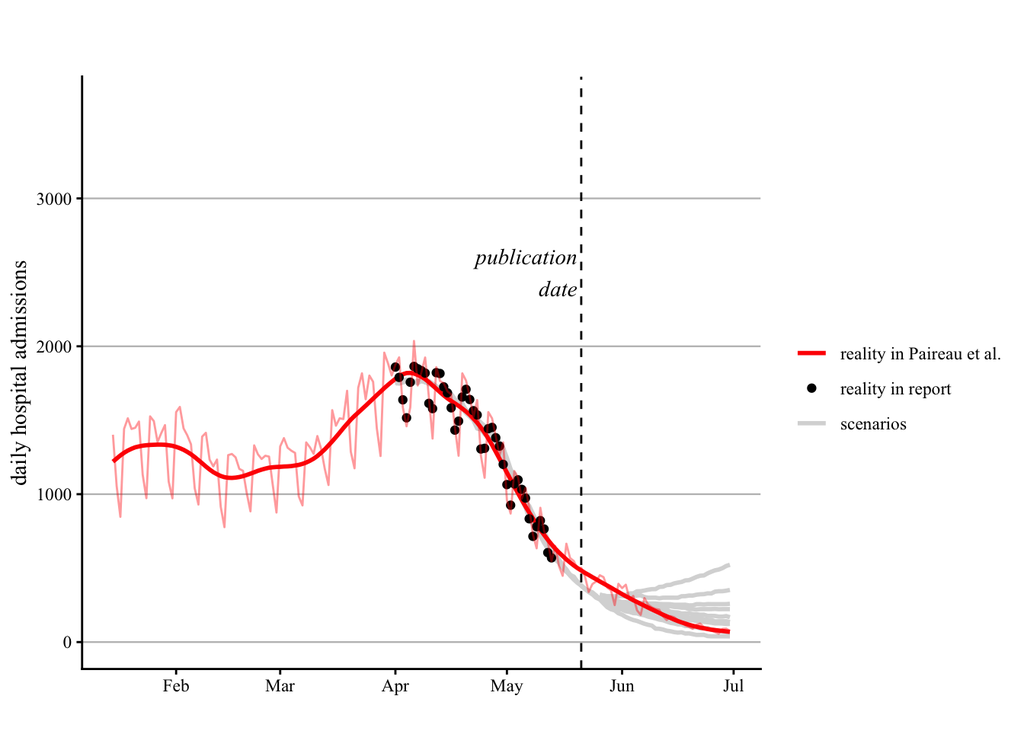

```r
scenarios <- read_csv("source_data/2021_05_21/new_hosp.csv") %>%
  mutate(date = as.Date(date, format = "%Y/%m/%d", optional = T))

f_graph(
  reality_new_hosp_adm, scenarios,
  "new_hosp_smooth",
  "2021-05-21", 2500, #publication date label
  "2021-01-15", "2021-06-30", #date limits
  NA, # y limits
  "daily hospital admissions",
  "reality in Paireau et al."
) +
  geom_line(data = reality_new_hosp_adm, aes(date, new_hosp), alpha=.4, color="red")
```

```r
#prepare data
temp <- f_prepare_to_save(
  scenarios,
  reality_new_hosp_adm %>% select(date, new_hosp_smooth),
  "new_hosp_smooth"
  )
temp <- temp %>% filter(date<=as.Date("2021-06-15")) #stop comparison mid-June before delta variant dominant

#save data
f_save_csv_files(temp, output_path, "2021_05_21_new_hosp.csv")
```

#### Error

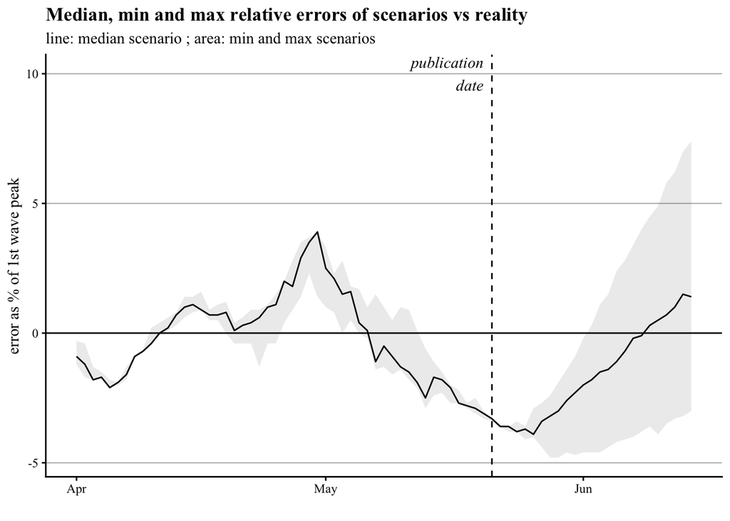

```r
error <- f_compute_error("2021-03-15", "2021-06-15", temp, max_new_hosp)

f_graph_error(
  error,
  "2021-05-21", 10 #publication date label
  )
```

```r
f_save_csv_files(error, output_path_error, "2021_05_21_new_hosp_error.csv")
```

#### Original

##### fig 1A

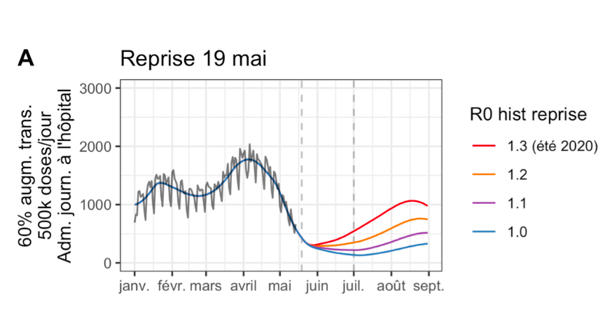

##### fig 1C

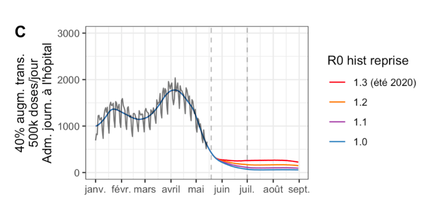

##### fig 1E

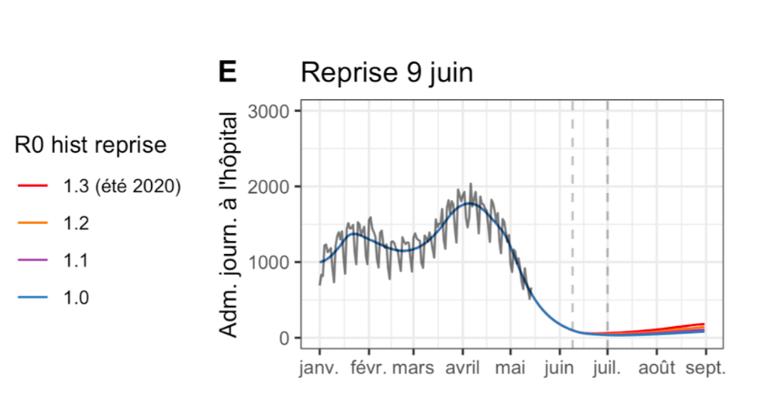

##### fig 1G

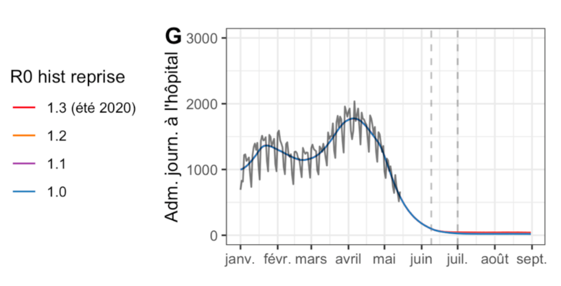

### July 26, 2021

Source: [Pasteur report](https://modelisation-covid19.pasteur.fr/variant/Institut_Pasteur_Acceleration_vaccination_et_Delta_20210726.pdf), July 26, 2021. Identified on Pasteur Institute’s website, on [this page](https://modelisation-covid19.pasteur.fr/realtime-analysis/delta-variant-dynamic/).

#### Reproduced

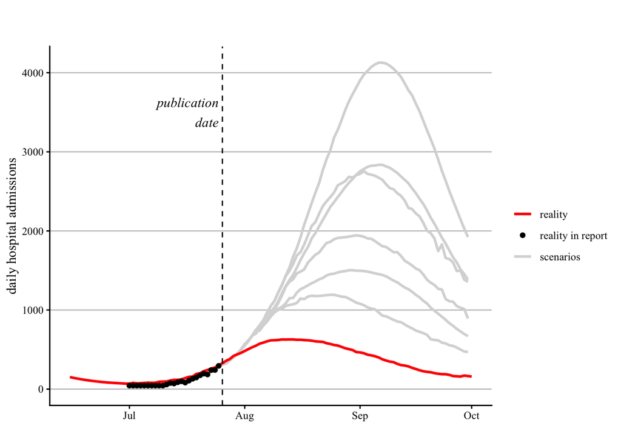

```r
#load scenarios
scenarios <- read_csv("source_data/2021_07_26/new_hosp.csv") %>%
  mutate(date = as.Date(date, format = "%Y/%m/%d", optional = T))

#graph comparison
f_graph(
  reality_new_hosp_adm, scenarios,
  "new_hosp_smooth",
  "2021-07-26", 3500, #publication date label
  "2021-06-15", "2021-10-01", #date limits
  NA, # y limits
  "daily hospital admissions",
  "reality"
)
```

```r
#prepare and save data
temp <- f_prepare_to_save(scenarios, reality_new_hosp_adm, "new_hosp_smooth")
f_save_csv_files(temp, output_path, "2021_07_26_new_hosp.csv")
```

#### Error

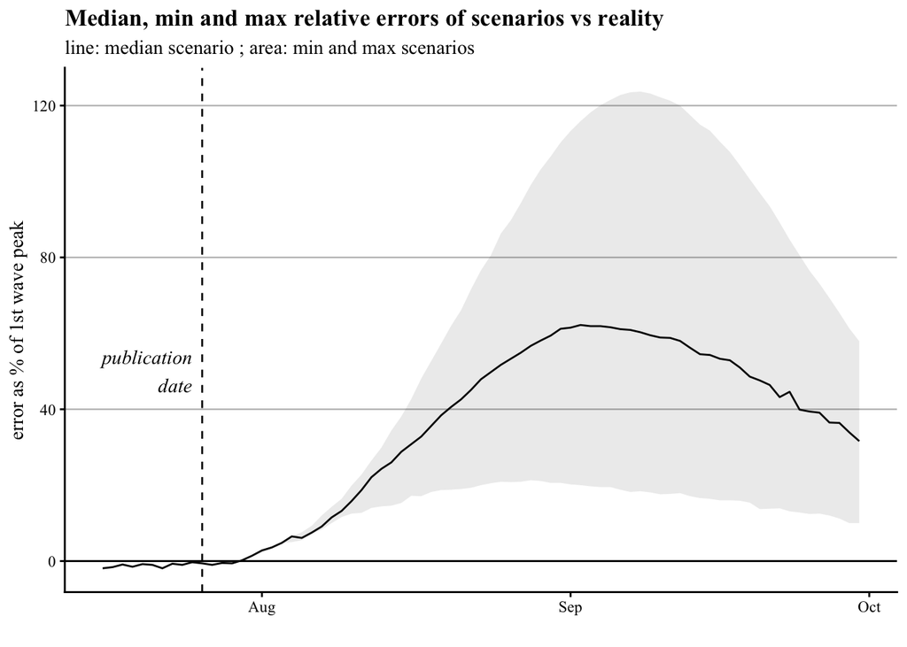

```r
error <- f_compute_error("2021-07-15", "2021-10-10", temp, max_new_hosp)

f_graph_error(
  error,
  "2021-07-26", 50 #publication date label
  )
```

```r
f_save_csv_files(error, output_path_error, "2021_07_26_new_hosp_error.csv")
```

#### Original

##### Fig 3 zoomes

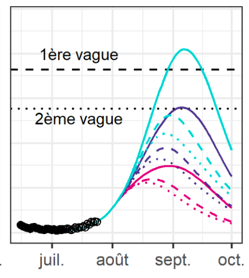

```r
knitr::include_graphics("source_data/2021_07_26/2021_07_26_fig3_zoom.png")
```

##### Fig 3 all

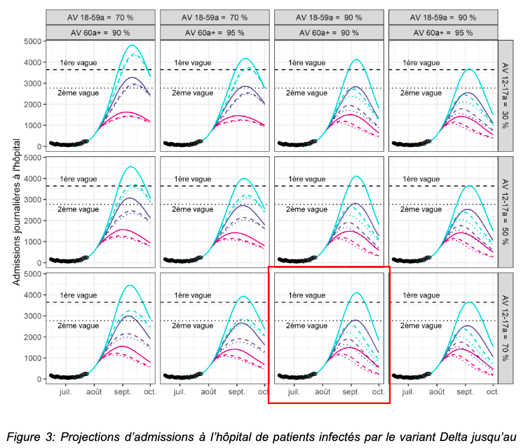

```r
knitr::include_graphics("source_data/2021_07_26/2021_07_26_fig3.png")
```

### August 5, 2021

Source: [Pasteur report](https://modelisation-covid19.pasteur.fr/variant/InstitutPasteur_Dynamiques_regionales_des_hospitalisations_20210805.pdf), August 5, 2021. Identified on Pasteur Institute’s website, on [this page](https://modelisation-covid19.pasteur.fr/realtime-analysis/delta-variant-dynamic/).

#### Reproduced

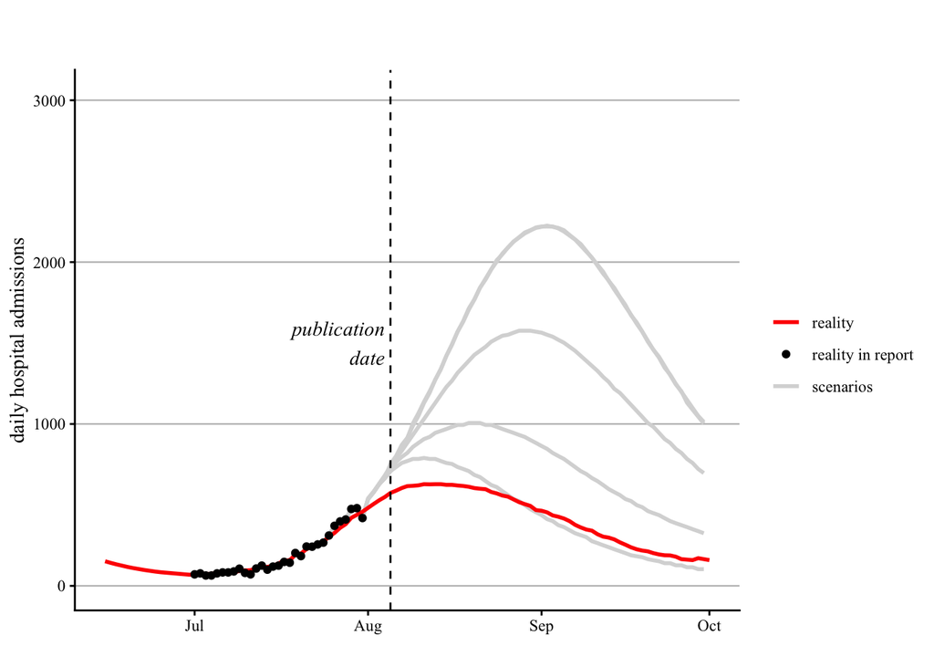

```r
#load scenario
scenarios <- read_csv("source_data/2021_08_05/new_hosp.csv") %>%
  mutate(date = as.Date(date, format = "%Y/%m/%d", optional = T))

#graph comparison
f_graph(
  reality_new_hosp_adm, scenarios,
  "new_hosp_smooth",
  "2021-08-05", 1500, #publication date label
  "2021-06-15", "2021-10-01", #date limits
  NA, # y limits
  "daily hospital admissions",
  "reality"
)
```

```r
#prepare and save data
temp <- f_prepare_to_save(scenarios, reality_new_hosp_adm, "new_hosp_smooth")
f_save_csv_files(temp, output_path, "2021_08_05_new_hosp.csv")
```

#### Error

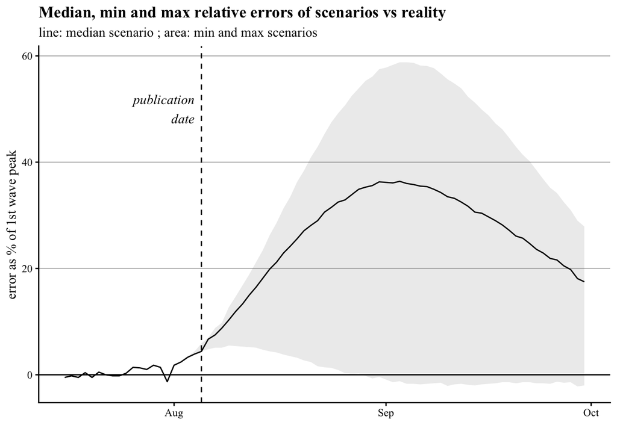

```r
error <- f_compute_error("2021-07-15", "2021-10-10", temp, max_new_hosp)

f_graph_error(
  error,
  "2021-08-05", 50 #publication date label
  )
```

```r
f_save_csv_files(error, output_path_error, "2021_08_05_new_hosp_error.csv")
```

#### Original

##### Fig A

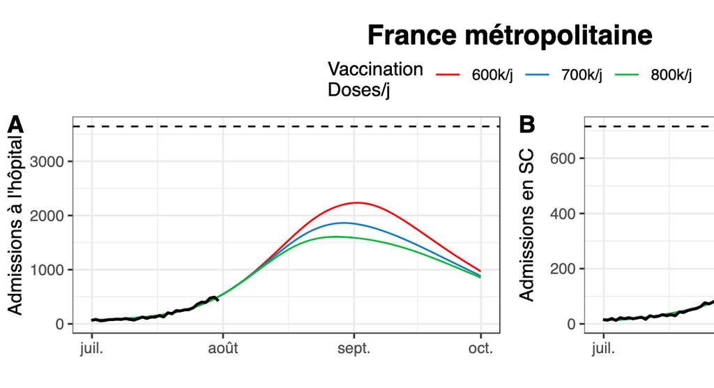

##### Fig C

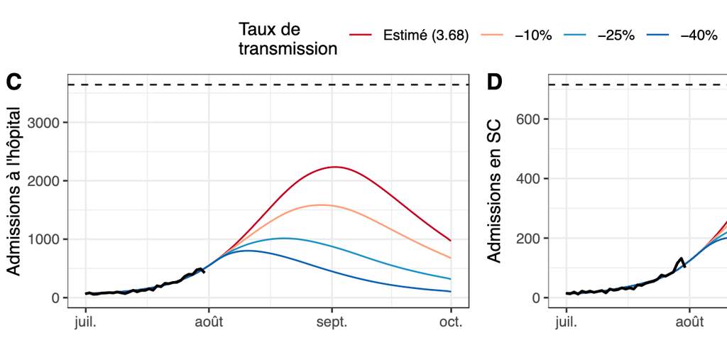

### October 4, 2021

Source: [Pasteur report](https://modelisation-covid19.pasteur.fr/scenarios/InstitutPasteur_scenariosCOVID19AutomneHiver_2021.pdf), October 4, 2021. Identified on Pasteur Institute’s website, on [this page](https://modelisation-covid19.pasteur.fr/realtime-analysis/fall-winter-scenarios/).

#### Reproduced

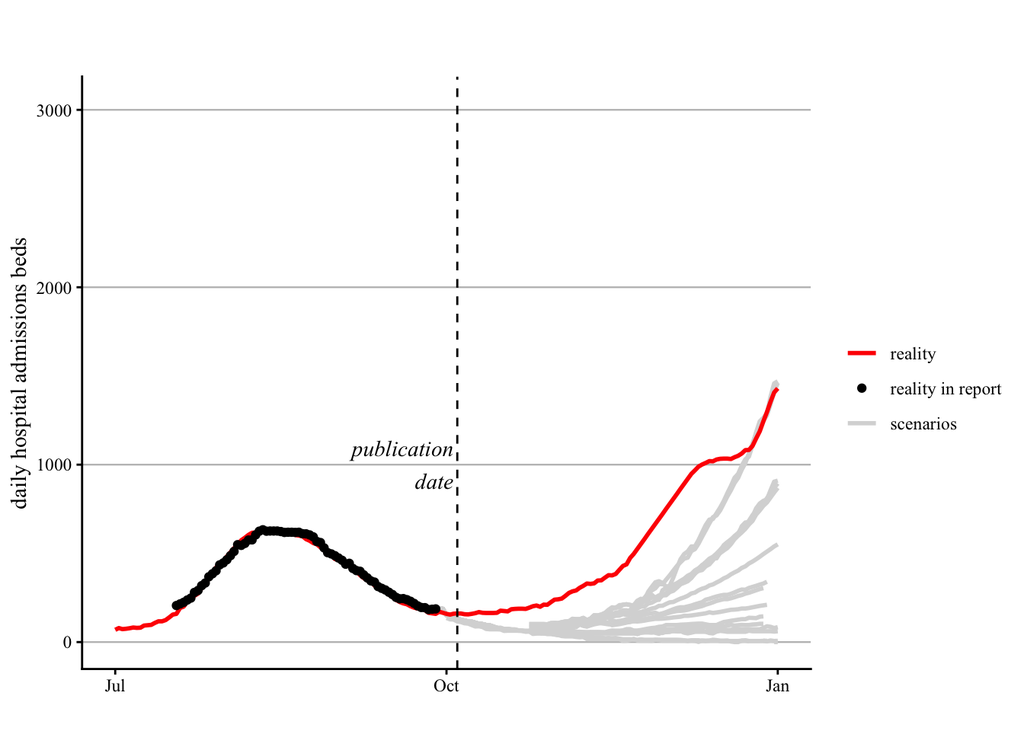

```r
#load scenarios
scenarios <- read_csv("source_data/2021_10_04/new_hosp.csv") %>%
  mutate(date = as.Date(date, format = "%Y/%m/%d", optional = T))

#graph comparison
f_graph(
  reality_new_hosp_adm, scenarios,
  "new_hosp_smooth",
  "2021-10-04", 1000, #publication date label
  "2021-07-01", "2022-01-01", #date limits
  NA, # y limits
  "daily hospital admissions beds",
  "reality"
)
```

```r
#prepare and save data
temp <- f_prepare_to_save(scenarios, reality_new_hosp_adm, "new_hosp_smooth")
temp <- temp %>% filter(date <= as.Date("2021-12-15")) #stop comparison before Omicron dominance in mid-December
f_save_csv_files(temp, output_path, "2021_10_04_new_hosp.csv")
```

#### Error

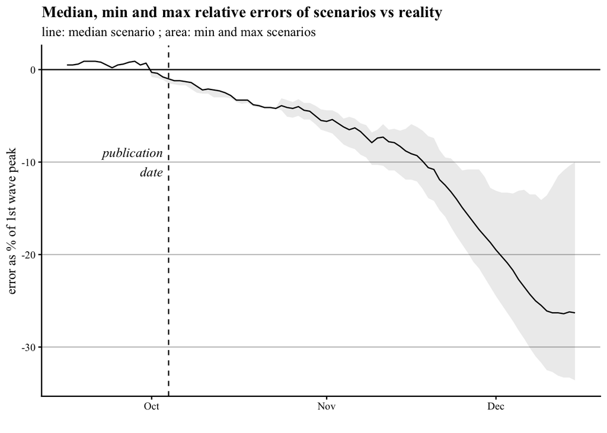

```r
error <- f_compute_error("2021-09-15", "2021-12-20", temp, max_new_hosp)

f_graph_error(
  error,
  "2021-10-04", -10 #publication date label
  )
```

```r
f_save_csv_files(error, output_path_error, "2021_10_04_new_hosp_error.csv")
```

#### Original

##### Fig 9

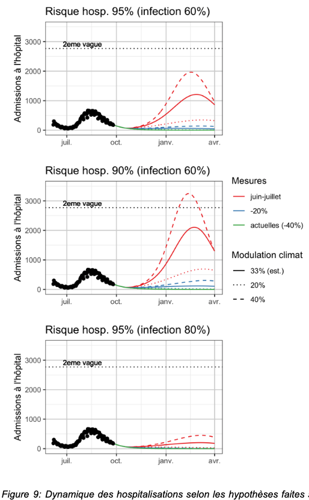

### January 7, 2022

Source: [Pasteur report](https://modelisation-covid19.pasteur.fr/variant/InstitutPasteur_Complement_Analyse_Impact_Omicron_20220107_corrige.pdf), January 7, 2022. Identified on Pasteur Institute’s website, on [this page](https://modelisation-covid19.pasteur.fr/realtime-analysis/omicron-variant-epidemic/).

#### Reproduced

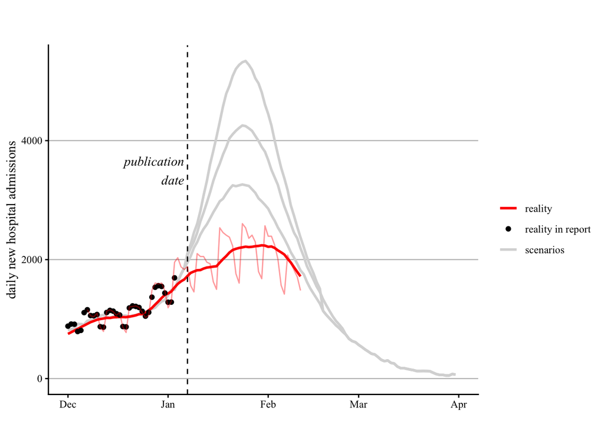

```r
#load data
scenarios <- read_csv("source_data/2022_01_07/new_hosp_low_VE.csv") %>%
  mutate(date = as.Date(date, format = "%Y/%m/%d", optional = T))

#graph comparison
f_graph(
  reality_new_hosp_adm, scenarios,
  "new_hosp_smooth",
  "2022-01-07", 3500, #publication date label
  "2021-12-01", "2022-04-01", #date limits
  NA, # y limits
  "daily new hospital admissions",
  "reality"
) +
  geom_line(
    data = reality_new_hosp_adm,
    aes(date, new_hosp), alpha = .4, color = "red"
  )
```

```r
#prepare and save data
temp <- f_prepare_to_save(scenarios, reality_new_hosp_adm, "new_hosp_smooth")
f_save_csv_files(temp, output_path, "2022_01_07_new_hosp.csv")
```

#### Error

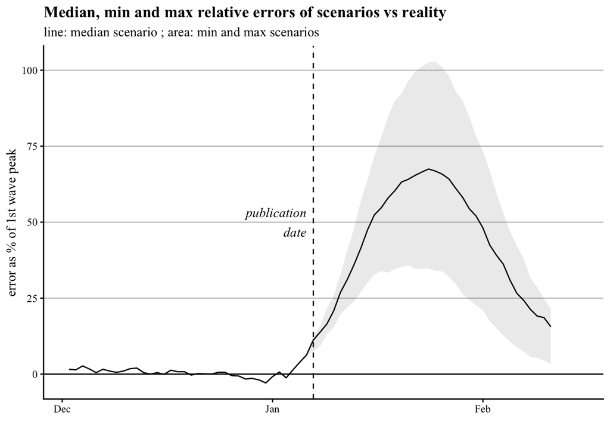

```r
error <- f_compute_error("2021-12-01", "2022-04-01", temp, max_new_hosp)

f_graph_error(
  error,
  "2022-01-07", 50 #publication date label
  ) +
  xlim(as.Date(NA), as.Date("2022-02-15")) #we do not have reality data past Feb 11
```

```r
f_save_csv_files(error, output_path_error, "2022_01_07_new_hosp_error.csv")
```

#### Original

##### Figure 4 zoomed

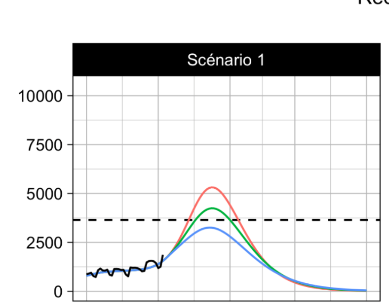

##### Figure 4 all

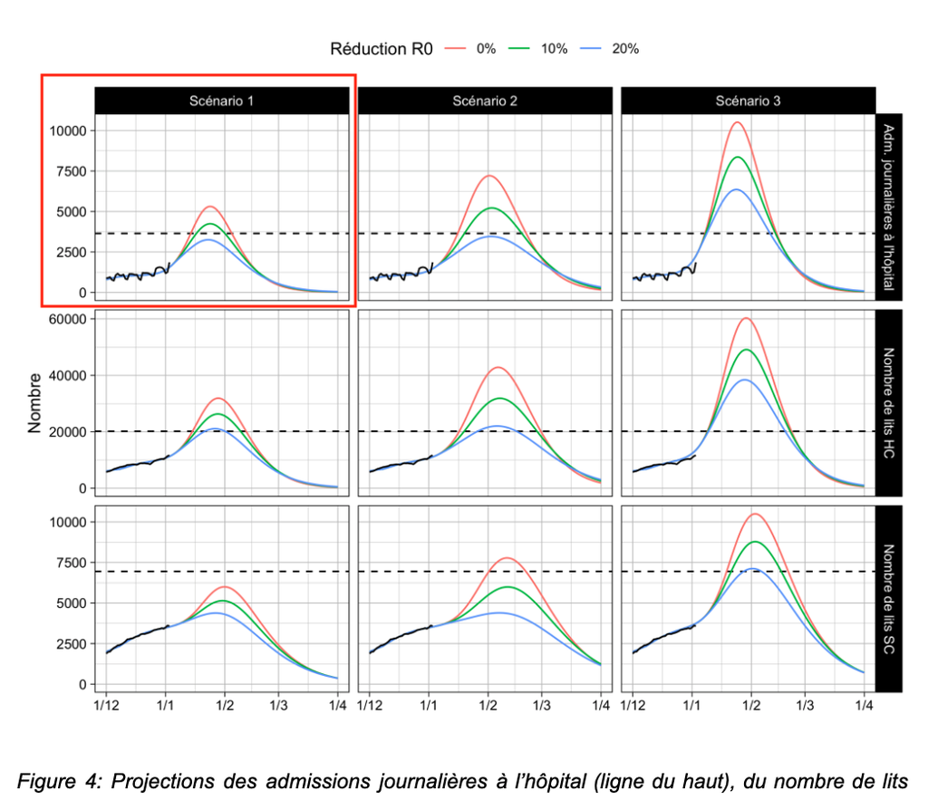

```r
#remove temporary variables
rm(error, temp, temp2, scenarios)
```

# Results

## All reports grouped

```r
path_source <- "output_data/extracted_data/"

#combine all ICU scenarios data for whole France
data_ICU_beds <- bind_rows(lapply(
  c("2020_10_30", "2021_05_21", "2021_07_26", "2021_08_05", "2022_01_07"),
  f_read_ICU
  ))

#combine all new scenarios hosp data for whole France
data_new_hosp <- bind_rows(lapply(
  c("2021_02_08", "2021_02_14", "2021_02_23", "2021_04_26", "2021_05_21", "2021_07_26", "2021_08_05", "2021_10_04", "2022_01_07"),
  f_read_new_hosp
  ))

# compute error relative to max ICU occupancy or max new hosp admissions  (used for colored scenarios in graph)
data_ICU_beds <- f_gather_scenarios_compute_relative_error(data_ICU_beds, max_ICU_beds)
data_new_hosp <- f_gather_scenarios_compute_relative_error(data_new_hosp, max_new_hosp)

# remove scenarios data before report publication date; remove empty values
data_ICU_beds <- data_ICU_beds %>%
  group_by(report) %>%
  filter(
    date>=as.Date(report),
    is.na(value)==F
    )
data_new_hosp <- data_new_hosp %>%
  group_by(report) %>%
  filter(
    date>=as.Date(report),
    is.na(value)==F
    )
```

```r
# min and max dates of 1st wave and scenarios period, for the limits of the 2 different panes on graph
date_first_wave_min <- min(reality_ICU_beds$date)
date_first_wave_max <- as.Date("2020-06-01")
date_scenarios_min <- min(data_ICU_beds$date)
date_scenarios_max <- max(data_ICU_beds$date)

# for the relative width of the 2 panes
first_wave_duration <- as.numeric(date_first_wave_max-date_first_wave_min)
scenarios_duration <- as.numeric(date_scenarios_max-date_scenarios_min)
first_wave_rel_duration <- first_wave_duration /(first_wave_duration+scenarios_duration)
scenarios_rel_duration <- scenarios_duration /(first_wave_duration+scenarios_duration)
```

### ICU

```r
# get max error for color scale
max_error <- max(data_ICU_beds$error, na.rm = T)

# collect dates of the reports and number of reports (used for x axis)
report_dates_ICU <- data_frame(
  report = unique(as.Date(data_ICU_beds$report)), # dates of reports
  place = report # to localize on x axis
)
n_reports <- as.numeric(nrow(report_dates_ICU))

#reorder and rename report names in more explicit dates
data_ICU_beds <- data_ICU_beds %>%
  mutate(
    report_date = report,
    report = format(as.Date(report_date), format="%b %d, %Y")
  )
data_ICU_beds$report <- factor(
  data_ICU_beds$report,
  levels = c(
    "Oct 30, 2020",
    "May 21, 2021",
    "Jul 26, 2021",
    "Aug 05, 2021",
    "Jan 07, 2022"
  )
)
#small offset to position summer 2021 reports because they are too close
report_dates_ICU$place[report_dates_ICU$place=="2021-07-26"] <- report_dates_ICU$place[report_dates_ICU$place=="2021-07-26"]-10
report_dates_ICU$place[report_dates_ICU$place=="2021-08-05"] <- report_dates_ICU$place[report_dates_ICU$place=="2021-08-05"]+3
```

```r
# pane of reality data only for 1st wave to show peak
g1_first_wave <- ggplot(reality_ICU_beds %>% filter(date<date_first_wave_max)) +

  #1st lockdown
  #annotate(geom = "rect", xmin = as.Date("2020-03-17"), xmax = as.Date("2020-05-11"), ymin = -Inf, ymax=Inf, alpha=.2) +

  # line of real ICU beds occupancy
  geom_line(
    aes(date, ICU_beds, linetype="reality")
    ) +
  # horizontal line showing max ICU occupancy
  geom_hline(
    yintercept = max_ICU_beds, linetype="dashed"
    ) +
  # and its annotation
  annotate(
    'text', x = as.Date("2020-03-05"), y = max_ICU_beds, label = "1st wave\npeak in\nApril 2020",
    color = "black", fontface = "italic", family = "Times New Roman", vjust=-.2, hjust=0
    ) +
  # other graph parameters
  theme(
    legend.position = "none",
    axis.text.x = element_blank(),
    axis.ticks.x = element_blank()
    ) +
  coord_cartesian(
    expand=F, xlim = c(date_first_wave_min,NA), ylim = c(0, NA)
    )  +
  labs(
    x = element_blank(),
    y = "ICU beds\noccupied by COVID patients"
    )

# pane of scenarios vs reality
g1_scenarios <- ggplot(data_ICU_beds) +

  #2nd lockdown
  #annotate(geom = "rect", xmin = as.Date("2020-10-30"), xmax = as.Date("2020-12-15"), ymin = -Inf, ymax=Inf, alpha=.2) +

  #3rd lockdown
  #annotate(geom = "rect", xmin = as.Date("2021-03-19"), xmax = as.Date("2021-05-03"), ymin = -Inf, ymax=Inf, alpha=.2) +

  #curfew
  #annotate(geom = "segment", x = as.Date("2020-12-15"), xend = as.Date("2021-06-20"), y = 12000, yend=12000) +
  #annotate(geom="text", x = as.Date("2020-12-15"), y = 12000, label = "national curfew", color = "black", fontface = "italic", family = "Times New Roman", vjust=0, hjust=0) +

  #dates of reports on x axis
  geom_rug(
    data = report_dates_ICU, aes(report)
    ) +
  scale_x_continuous(
    breaks=report_dates_ICU$place,
    labels=format(report_dates_ICU$report, format="%b %d, %Y")
    ) +

  # scenarios curves and their colors
  geom_line(
    aes(date, value, group=interaction(scenario_type, report), color=abs(error)),
    linewidth=1.5
    ) +
  scale_colour_stepsn(
    colours = c("green", "orange", "red", "purple"),
    values = c(0, 15, 30, 100, round(max_error))/max_error,
    breaks = c(0, 15, 30, 100, round(max_error)),
    labels = c("0%", "± 15%", "± 30%", "± 100%", ""),
  ) +

  # reality curve
  geom_line(
    data=reality_ICU_beds %>% filter(date>date_scenarios_min-15),
    aes(date, ICU_beds, linetype="reality")) +

  # annotation 1st wave peak in France
  geom_hline(
    yintercept = max_ICU_beds, linetype="dashed"
    ) +

  # other parameters
  theme(
    axis.text.x = element_text(angle = 45, hjust=1),
    axis.ticks.x=element_blank(),
    axis.line.y = element_blank(),
    axis.text.y = element_blank(),
    axis.ticks.y = element_blank()
    ) +
  coord_cartesian(
    expand=F, xlim = c(date_scenarios_min-15,NA), ylim = c(0, NA)
    )  +
  labs(
    x = paste("publication dates of the", n_reports, "reports"),
    y=element_blank(), x=element_blank(),
    color=" error of scenario\n  as % of\n 1st wave peak",
    linetype= element_blank()
    )
```

with colored errors

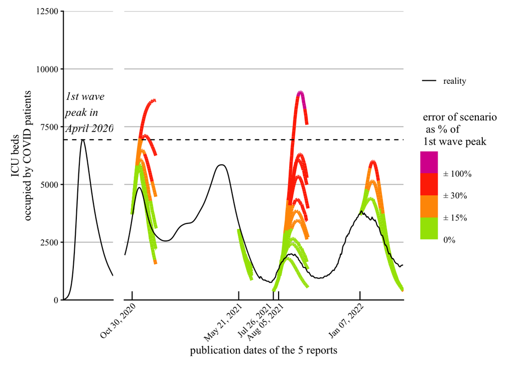

```r
# combination of the 2 panes
g1 <- g1_first_wave + g1_scenarios +
  plot_layout(widths = c(first_wave_rel_duration, scenarios_rel_duration)) &
  ylim(0, 12500)
g1
```

```r
#save
f_save_graph_pdf_png(
  "../graphs/raw_comparisons/all_ICU_scenarios_reality",
  7, 4, dpi_resolution
)
```

without colored errors

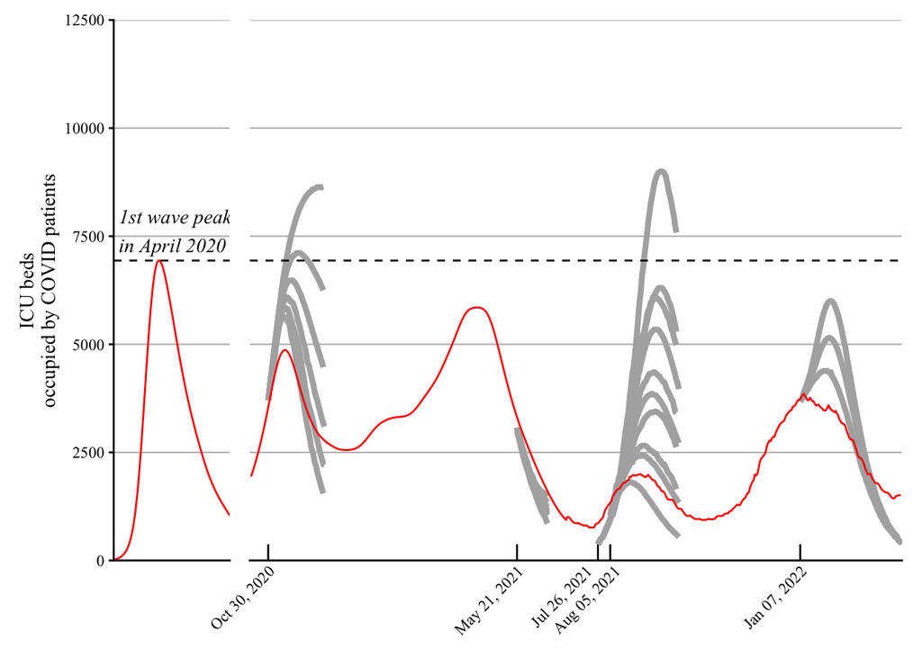

```r
# --- ICU: same figure but without colored errors ---
# - reality in red
# - scenarios in grey (slightly darker)
# - no error legend

# pane of reality data only for 1st wave to show peak
g1_first_wave_grey <- ggplot(reality_ICU_beds %>% filter(date < date_first_wave_max)) +
  geom_line(
    aes(date, ICU_beds),
    color = "#ff0000"
  ) +
  geom_hline(
    yintercept = max_ICU_beds,
    linetype = "dashed"
  ) +
  annotate(
    "text",
    x = as.Date("2020-03-05"), y = max_ICU_beds,
    label = "1st wave peak\nin April 2020",
    color = "black", fontface = "italic", family = "Times New Roman",
    vjust = -.2, hjust = 0
  ) +
  theme(
    legend.position = "none",
    axis.text.x = element_blank(),
    axis.ticks.x = element_blank()
  ) +
  coord_cartesian(
    expand = FALSE,
    xlim = c(date_first_wave_min, NA),
    ylim = c(0, NA)
  ) +
  labs(
    x = element_blank(),
    y = "ICU beds\noccupied by COVID patients"
  )

# pane of scenarios vs reality (no error colors)
g1_scenarios_grey <- ggplot(data_ICU_beds) +
  # dates of reports on x axis
  geom_rug(
    data = report_dates_ICU,
    aes(report)
  ) +
  scale_x_continuous(
    breaks = report_dates_ICU$place,
    labels = format(report_dates_ICU$report, format = "%b %d, %Y")
  ) +
  # scenarios curves in grey (darker than before)
  geom_line(
    aes(date, value, group = interaction(scenario_type, report)),
    color = "#B0B0B0",
    linewidth = 1.5
  ) +
  # reality curve in red
  geom_line(
    data = reality_ICU_beds %>% filter(date > date_scenarios_min - 15),
    aes(date, ICU_beds),
    color = "#ff0000"
  ) +
  # annotation 1st wave peak in France
  geom_hline(
    yintercept = max_ICU_beds,
    linetype = "dashed"
  ) +
  theme(
    legend.position = "none",
    axis.text.x = element_text(angle = 45, hjust = 1),
    axis.ticks.x = element_blank(),
    axis.line.y = element_blank(),
    axis.text.y = element_blank(),
    axis.ticks.y = element_blank()
  ) +
  coord_cartesian(
    expand = FALSE,
    xlim = c(date_scenarios_min - 15, NA),
    ylim = c(0, NA)
  ) +
  labs(
    x = element_blank(),
    y = element_blank()
  )

# combination of the 2 panes
g1_grey <- g1_first_wave_grey + g1_scenarios_grey +
  plot_layout(widths = c(first_wave_rel_duration, scenarios_rel_duration)) &
  ylim(0, 12500)

g1_grey
```

### New hospitalizations

```r
#max error for color scale
max_error <- max(data_new_hosp$error, na.rm = T)

#date of the reports
report_dates_hosp <- data_frame(
  report = unique(as.Date(data_new_hosp$report)),
  place = report #to localize on x axis
)
#number of reports
n_reports <- as.numeric(nrow(report_dates_hosp))

data_new_hosp <- data_new_hosp %>%
  mutate(
    report_date = report,
    report = format(as.Date(report_date), format="%b %d, %Y")
  )

#reorder report and rename them with more explicit date
data_new_hosp$report <- factor(
  data_new_hosp$report,
  levels = c(
    "Feb 08, 2021",
    "Feb 14, 2021",
    "Feb 23, 2021",
    "Apr 26, 2021",
    "May 21, 2021",
    "Jul 26, 2021",
    "Aug 05, 2021",
    "Oct 04, 2021",
    "Jan 07, 2022"
  )
)

#small offset to position summer 2021 reports
report_dates_hosp$place[report_dates_hosp$place=="2021-07-26"] <- report_dates_hosp$place[report_dates_hosp$place=="2021-07-26"]-5
report_dates_hosp$place[report_dates_hosp$place=="2021-08-05"] <- report_dates_hosp$place[report_dates_hosp$place=="2021-08-05"]+5
#small offset to position winter 2021 reports
report_dates_hosp$place[report_dates_hosp$place=="2021-02-08"] <- report_dates_hosp$place[report_dates_hosp$place=="2021-02-08"]-1
report_dates_hosp$place[report_dates_hosp$place=="2021-02-14"] <- report_dates_hosp$place[report_dates_hosp$place=="2021-02-14"]+8
report_dates_hosp$place[report_dates_hosp$place=="2021-02-23"] <- report_dates_hosp$place[report_dates_hosp$place=="2021-02-23"]+15

# min and max dates of 1st wave and scenarios period, for the 2 different panes on graph
# date_first_wave_min <- min(reality_new_hosp_adm$date)
# date_first_wave_max <- as.Date("2020-06-01")
# date_scenarios_min <- min(data_new_hosp$date)
# date_scenarios_max <- max(data_new_hosp$date)
```

```r
#plot 1st wave
g2_first_wave <- ggplot(reality_new_hosp_adm %>% filter(date<date_first_wave_max)) +
  geom_line(
    aes(date, new_hosp_smooth, linetype="reality")
    ) +
  geom_line(
    aes(date, new_hosp), alpha=.2
    ) +
  geom_hline(
    yintercept = max_new_hosp, linetype="dashed"
    ) +
  theme(
    legend.position = "none",
    axis.text.x = element_blank(),
    axis.ticks.x = element_blank()
    ) +
  coord_cartesian(
    expand=F, xlim = c(date_first_wave_min,NA), ylim = c(0, NA)
    )  +
  labs(
    x = element_blank(),
    y = "daily new hospital admissions\nrelated to COVID") +
  annotate(
    'text', x = as.Date("2020-03-05"), y = max_new_hosp, label = "1st wave\npeak in\nApril 2020",
    color = "black", fontface = "italic", family = "Times New Roman", vjust=-.2, hjust=0
    )

#plot scenarios
g2_scenarios <- ggplot(data_new_hosp) +

  #dates of reports on x axis
  geom_rug(
    data = report_dates_hosp, aes(report)
    ) +
  scale_x_continuous(
    breaks=report_dates_hosp$place,
    labels=format(report_dates_hosp$report, format="%b %d, %Y")
    ) +

  # un-smoothed reality
  geom_line(
    data=reality_new_hosp_adm %>% filter(date>date_scenarios_min-15),
    aes(date, new_hosp), alpha=.2
    ) +

  # scenarios curves and their colors
  geom_line(
    aes(date, value, group=interaction(scenario_type, report), color=abs(error)),
    linewidth=1
    ) +
  scale_colour_stepsn(
    colours = c("green", "orange", "red", "purple"),
    values = c(0, 15, 30, 100, round(max_error))/max_error,
    breaks = c(0, 15, 30, 100, round(max_error)),
    labels = c("0%", "± 15%", "± 30%", "± 100%", ""),
  ) +

  # reality curve
  geom_line(
    data=reality_new_hosp_adm %>% filter(date>date_scenarios_min-15),
    aes(date, new_hosp_smooth, linetype="reality")
    ) +

  # annotation peak 1st wave
  geom_hline(
    yintercept = max_new_hosp, linetype="dashed"
    ) +

  #other parameters
  coord_cartesian(
    expand=F, xlim = c(date_scenarios_min-15,NA), ylim = c(0, NA)
    )  +
  theme(
    axis.text.x = element_text(angle = 45, hjust=1),
    axis.ticks.x=element_blank(),
    axis.line.y = element_blank(),
    axis.text.y = element_blank(),
    axis.ticks.y = element_blank()
    ) +
  labs(
    x = paste("publication dates of the", n_reports, "reports"),
    y=element_blank(), x=element_blank(),
    color=" error of scenario\n  as % of\n 1st wave peak",
    linetype=element_blank()
  )
```

colored errors

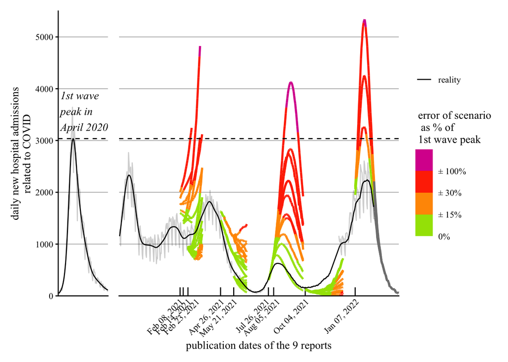

```r
g2 <- g2_first_wave + g2_scenarios +
  plot_layout(widths = c(first_wave_rel_duration, scenarios_rel_duration)) &
  ylim(0, 5500)
g2
```

```r
#save
f_save_graph_pdf_png(
  "../graphs/raw_comparisons/all_hosp_scenarios_reality",
  7, 4, dpi_resolution
)
```

not colored

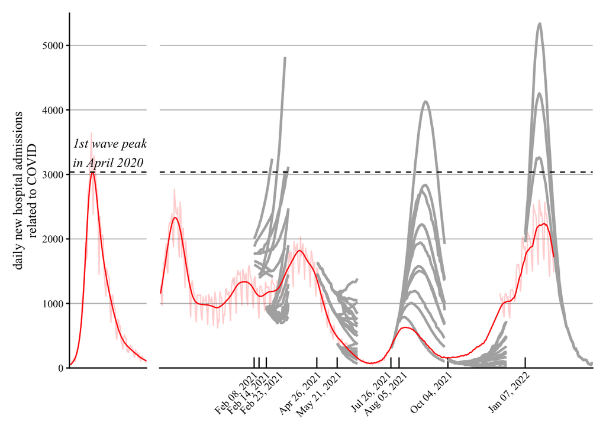

```r
# --- New hospitalizations: same figure but without colored errors ---
# - reality in red
# - scenarios in grey (slightly darker)
# - no error legend

# plot 1st wave (reality only)
g2_first_wave_grey <- ggplot(reality_new_hosp_adm %>% filter(date < date_first_wave_max)) +
  # smoothed reality in red
  geom_line(
    aes(date, new_hosp_smooth),
    color = "#ff0000"
  ) +
  # unsmoothed reality in red (lighter via alpha)
  geom_line(
    aes(date, new_hosp),
    color = "#ff0000", alpha = .2
  ) +
  # peak line
  geom_hline(
    yintercept = max_new_hosp,
    linetype = "dashed"
  ) +
  theme(
    legend.position = "none",
    axis.text.x = element_blank(),
    axis.ticks.x = element_blank()
  ) +
  coord_cartesian(
    expand = FALSE,
    xlim = c(date_first_wave_min, NA),
    ylim = c(0, NA)
  ) +
  labs(
    x = element_blank(),
    y = "daily new hospital admissions\nrelated to COVID"
  ) +
  annotate(
    "text",
    x = as.Date("2020-03-05"), y = max_new_hosp,
    label = "1st wave peak\nin April 2020",
    color = "black", fontface = "italic", family = "Times New Roman",
    vjust = -.2, hjust = 0
  )

# plot scenarios vs reality (no error colors)
g2_scenarios_grey <- ggplot(data_new_hosp) +
  # dates of reports on x axis
  geom_rug(
    data = report_dates_hosp,
    aes(report)
  ) +
  scale_x_continuous(
    breaks = report_dates_hosp$place,
    labels = format(report_dates_hosp$report, format = "%b %d, %Y")
  ) +
  # un-smoothed reality (red, light)
  geom_line(
    data = reality_new_hosp_adm %>% filter(date > date_scenarios_min - 15),
    aes(date, new_hosp),
    color = "#ff0000", alpha = .2
  ) +
  # scenarios curves in grey (darker than before)
  geom_line(
    aes(date, value, group = interaction(scenario_type, report)),
    color = "#B0B0B0",
    linewidth = 1
  ) +
  # smoothed reality curve in red
  geom_line(
    data = reality_new_hosp_adm %>% filter(date > date_scenarios_min - 15),
    aes(date, new_hosp_smooth),
    color = "#ff0000"
  ) +
  # annotation peak 1st wave
  geom_hline(
    yintercept = max_new_hosp,
    linetype = "dashed"
  ) +
  coord_cartesian(
    expand = FALSE,
    xlim = c(date_scenarios_min - 15, NA),
    ylim = c(0, NA)
  ) +
  theme(
    legend.position = "none",
    axis.text.x = element_text(angle = 45, hjust = 1),
    axis.ticks.x = element_blank(),
    axis.line.y = element_blank(),
    axis.text.y = element_blank(),
    axis.ticks.y = element_blank()
  ) +
  labs(
    x = element_blank(),
    y = element_blank()
  )

g2_grey <- g2_first_wave_grey + g2_scenarios_grey +
  plot_layout(widths = c(first_wave_rel_duration, scenarios_rel_duration)) &
  ylim(0, 5500)

g2_grey
```

### Both

colored errors

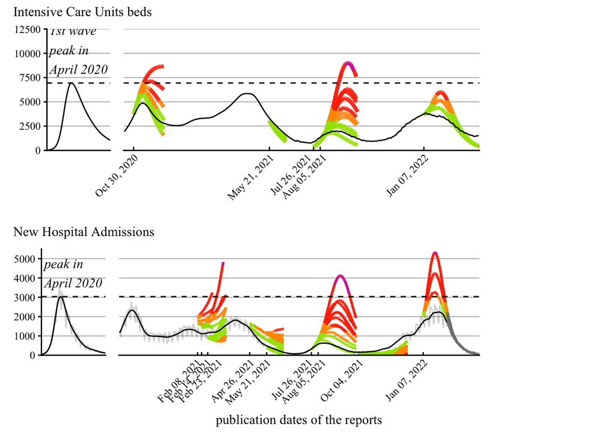

```r
#get common legend
p <- get_plot_component(g1, "guide-box", return_all = TRUE)

g1_b <-
  g1_first_wave + labs(y = element_blank()) +
  g1_scenarios + labs(x = element_blank()) + theme(legend.position = "none") +
  plot_annotation(subtitle = "Intensive Care Units beds") +
  plot_layout(widths = c(first_wave_rel_duration, scenarios_rel_duration)) &
  ylim(0, 12500)

g2_b <-
  g2_first_wave + labs(y = element_blank()) +
  g2_scenarios + labs(x = "publication dates of the reports") + theme(legend.position = "none") +
  plot_annotation(subtitle = "New Hospital Admissions") +
  plot_layout(widths = c(first_wave_rel_duration, scenarios_rel_duration)) &
  ylim(0, 5500)

#combine graphs
plot_grid(
  plot_grid(
    g1_b, g2_b, nrow=2
  ),
  p[[6]],
  ncol = 2, rel_widths = c(.8, .2)
)
```

```r
#save
f_save_graph_pdf_png(
  "../graphs/raw_comparisons/all_scenarios_reality",
  8, 8, dpi_resolution
)
```

not colored errors

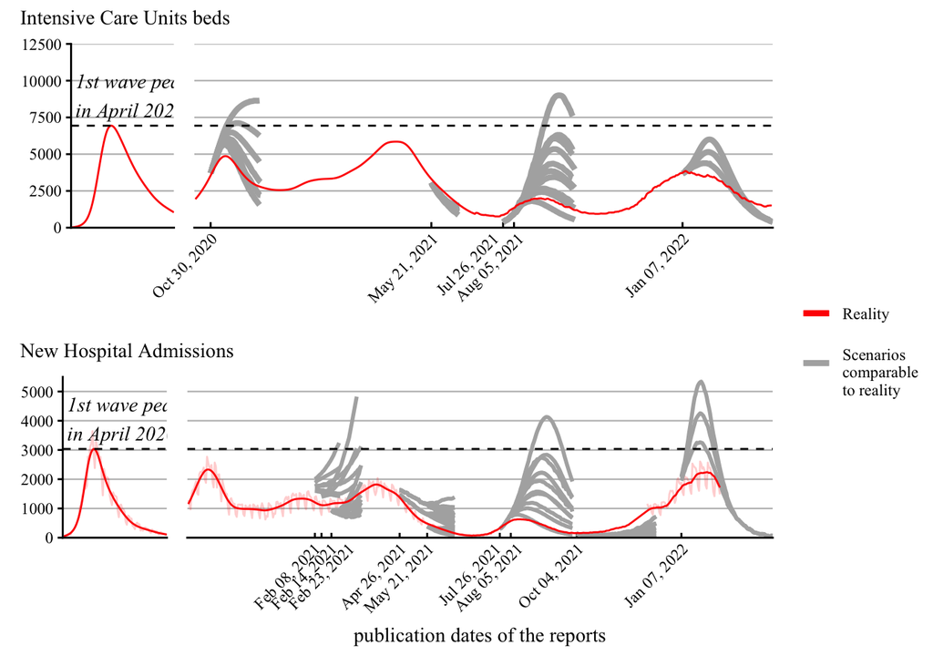

```r
# --- Combine ICU + New Hosp (no error colors) WITH a legend (reality vs scenarios) ---
# Assumes you already created:
#   g1_first_wave_grey, g1_scenarios_grey
#   g2_first_wave_grey, g2_scenarios_grey

label_scenarios <- "\nScenarios\ncomparable\nto reality"

# 1) Add a legend on ONE panel only (here: g2_scenarios_grey), and remove elsewhere
cols_legend <- setNames(
  c("#ff0000", "#B0B0B0"),
  c("Reality", label_scenarios)
)

g1_scenarios_grey <- g1_scenarios_grey + theme(legend.position = "none")

g2_scenarios_grey_leg <- g2_scenarios_grey +
  aes(color = NULL) +
  # Map colors to labels via invisible mapping (keeps geometry unchanged)
  geom_line(
    data = data_new_hosp %>% slice(1),
    aes(date, value, color = label_scenarios),
    alpha = 0
  ) +
  geom_line(
    data = reality_new_hosp_adm %>% slice(1),
    aes(date, new_hosp_smooth, color = "Reality"),
    alpha = 0
  ) +
  scale_color_manual(
    values = cols_legend,
    breaks = c("Reality", label_scenarios),
    name = ""
  ) +
  guides(
    color = guide_legend(override.aes = list(alpha = 1, linewidth = 1.5))
  ) +
  theme(legend.position = "right")

# Extract legend, then remove legend from plot panel
leg <- get_legend(g2_scenarios_grey_leg)
g2_scenarios_grey_noleg <- g2_scenarios_grey + theme(legend.position = "none")

# 2) Build the two combined rows (ICU / hosp)
g1_b_grey <-
  g1_first_wave_grey + labs(y = element_blank()) +
  g1_scenarios_grey + labs(x = element_blank()) +
  plot_annotation(subtitle = "Intensive Care Units beds") +
  plot_layout(widths = c(first_wave_rel_duration, scenarios_rel_duration)) &
  ylim(0, 12500)

g2_b_grey <-
  g2_first_wave_grey + labs(y = element_blank()) +
  g2_scenarios_grey_noleg + labs(x = "publication dates of the reports") +
  plot_annotation(subtitle = "New Hospital Admissions") +
  plot_layout(widths = c(first_wave_rel_duration, scenarios_rel_duration)) &
  ylim(0, 5500)

# 3) Combine with legend column
plot_grid(
  plot_grid(g1_b_grey, g2_b_grey, nrow = 2),
  leg,
  ncol = 2,
  rel_widths = c(.85, .15)
)
```

```r
# save
f_save_graph_pdf_png(
  "../graphs/raw_comparisons/all_scenarios_reality_no_error_colors",
  8, 6, dpi_resolution
)
```

## Comparison by modellers

### New hospitalizations

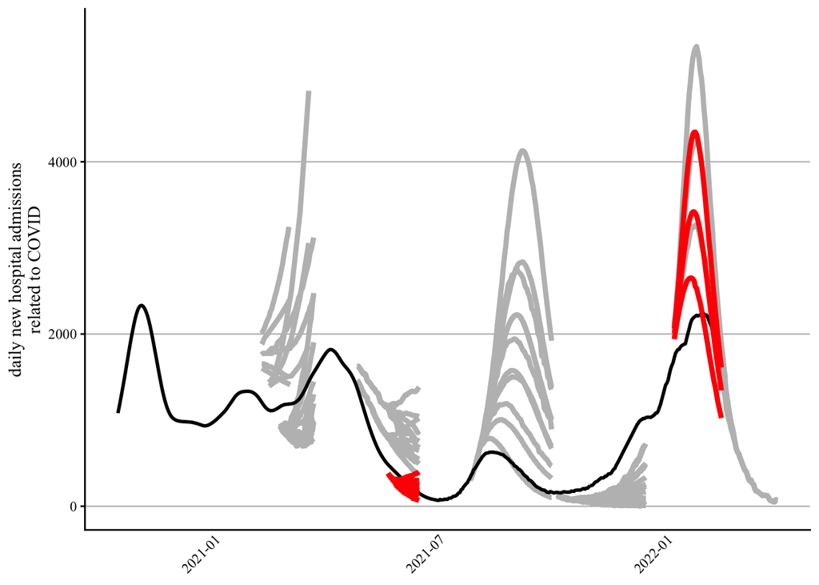

```r
temp <- bind_rows(

  # Jan 2022, illegitimate
  read_csv("source_data/improper_comparisons/improper_comparison_Jan_07_2022_new_hosp.csv") %>%
    gather(scenario_type, value, -date) %>%
    #the modelers stop their comparison on Feb 15
    filter(date<as.Date("2022-02-15") & date>=as.Date("2022-01-07")),

  # May 2021, legitimate
  data_new_hosp %>%
    filter(report == "May 21, 2021") %>%
    select(date, reality, scenario_type, value)
)



p2 <- ggplot(data_new_hosp) +
  theme(
    axis.text.x = element_text(angle = 45, hjust=1),
    axis.ticks.x=element_blank(),
    legend.position = "none"
    ) +

  #scenarios curves
  geom_line(
    aes(date, value, group=interaction(scenario_type, report)),
    linewidth=1.5, color="gray",
    ) +

  #reality
  geom_line(
    data=reality_new_hosp_adm %>% filter(date>=as.Date("2020-10-15")),
    aes(date, new_hosp_smooth, linetype="reality"),
    linewidth=1,
    ) +

  #scenario assessed by modelers
  geom_line(
    data = temp,
    aes(date, value, group=scenario_type),
    color="red", linewidth=1.5
    ) +

  labs(
    y="daily new hospital admissions\nrelated to COVID", x=element_blank(),
    color=" error of scenario\n  as % of\n 1st wave peak",
    linetype=element_blank()
  ) +
  ylim(0, 5500)

p2
```

### ICU

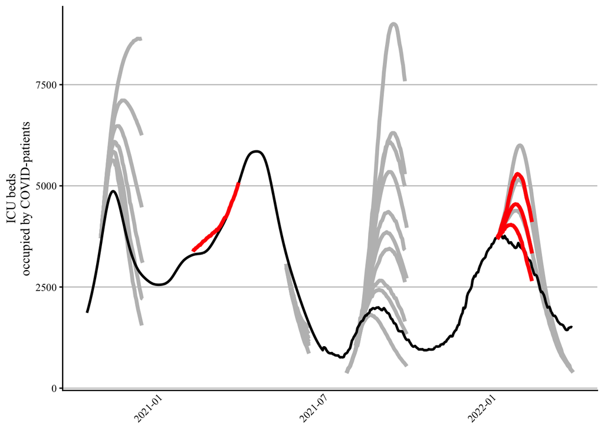

```r
#dataset of scenarios compared by modelers
temp <- bind_rows(

  #Feb 2021, illegitimate
  read_csv("source_data/improper_comparisons/improper_comparison_Feb_08_2021_ICU.csv") %>%
    #only 1 median scenario
    select(date, reality, value = med) %>%
    mutate(scenario_type = "median") %>%
    #starting April, lockdown in place
    filter(date<as.Date("2021-03-31") & date>=as.Date("2021-02-08")),

  # Jan 2022, illegitimate
  read_csv("source_data/improper_comparisons/improper_comparison_Jan_07_2022_ICU.csv") %>%
    gather(scenario_type, value, -c(date, reality)) %>%
    #the modelers stop their comparison on Feb 15
    filter(date<as.Date("2022-02-15") & date>=as.Date("2022-01-07"))
  )

p1 <- ggplot(data_ICU_beds) +
  theme(
    axis.text.x = element_text(angle = 45, hjust=1),
    axis.ticks.x=element_blank(),
    legend.position = "none"
    ) +

  #scenarios curves
  geom_line(
    aes(date, value, group=interaction(scenario_type, report)),
    linewidth=1.5, color="gray"
    ) +

  #reality national scale
  geom_line(
    data=reality_ICU_beds %>% filter(date>=as.Date("2020-10-15")),
    aes(date, ICU_beds, linetype="reality"),
    linewidth=1
    ) +

  #scenario assessed by modelers
  geom_line(
    data = temp,
    aes(date, value, group=scenario_type),
    color="red", linewidth=1.5
    ) +
  labs(
    x = element_blank(),
    y="ICU beds\noccupied by COVID-patients",
    linetype= element_blank()
  )

p1
```

### Both

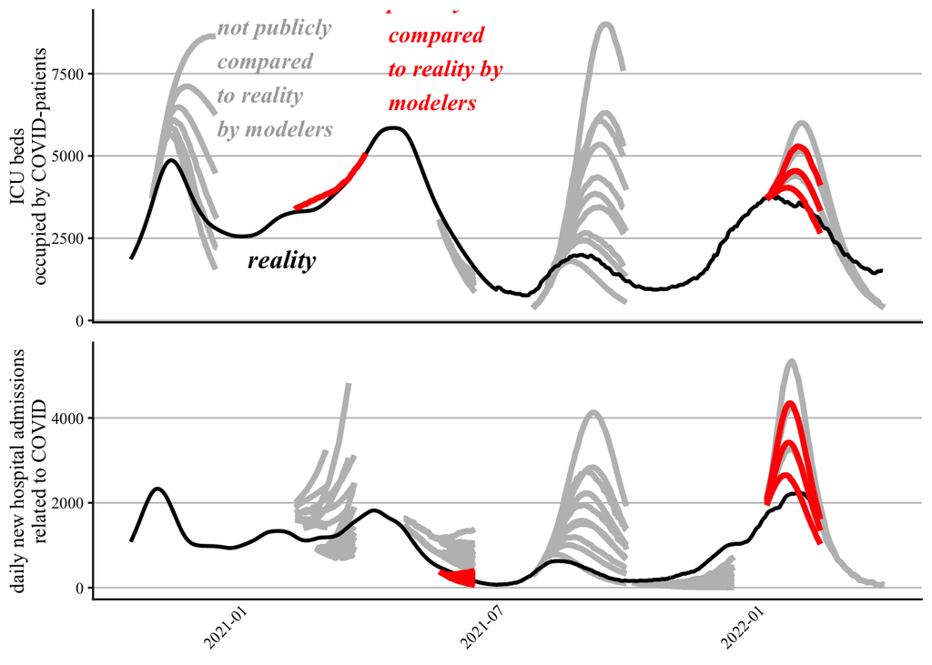

```r
plot_grid(
  p1 + theme(axis.text.x = element_blank()) +
     annotate(
      'text', x = as.Date("2021-01-30"), y = 1500, label = "reality",
      color = "black", fontface = "bold.italic", family = "Times New Roman",
      vjust=-0.2, size=5
      ) +
    annotate(
      'text', x = as.Date("2020-12-15"), y = 5600, label = "scenarios\nnot publicly\ncompared\nto reality\nby modelers",
      color = "darkgrey", fontface = "bold.italic", family = "Times New Roman",
      vjust=0, hjust=0, size=4.5
      ) +
    annotate(
      'text', x = as.Date("2021-04-15"), y = 6400, label = "scenarios\npublicly\ncompared\nto reality by\nmodelers",
      color = "red", fontface = "bold.italic", family = "Times New Roman",
      vjust=0, hjust=0, size=4.5
      ),
  p2,
  nrow=2
  )
```

```r
#save
f_save_graph_pdf_png(
  "../graphs/raw_comparisons/self_assessed_modellers",
  7, 7, dpi_resolution
)
```